# CS4423 Assignment 2: Part 2: answers

## Preliminaries

### Task 1.1: Give you name, ID, and list of collaborators

**Your name goes here:** Paul Erdős

**Your ID number goes here:** 12345678

I worked with Alfréd Rényi on this assignment

### Task 1.2: Load any Python modules, and choose your own colour for nodes

```python
import networkx as nx
### Change the next line so nodes appear in your favourite colour.
opts = { "with_labels": True, "node_color": '#FEDCBA' } # show labels; IMPORTANT: Choose your own colour here
```

Other ones that Niall used when preparing solutions. Add any you need:

```python
import numpy as np
import matplotlib.pyplot as plt
import random
import pandas as pd
import math
import statistics
```

## Centrality Measures

Before you do this set of tasks, it may be helpful to review the example at the end of [Week 7 Part 2](https://www.niallmadden.ie/2425-CS4423/W07/CS4423-W07-Part-2.html)

**Adjacency Lists**.  
One way of representing a graph is an as **adjacency list**. It has one row per node. That row starts with the node label, followed by a colon, followed by a list of its neighbours. For an undirected graph, one does not list an edge twice.

Consider the following list, for a graph, $G_1$, on the nodes $\{1, 2, 3, \dots, 10\}$:

```
1: 2 3 4 6 7
2: 3
3: 4
4: 5 8
5: 6
6: 7
7:
8: 9 10
9:
10:
```

### TASK 2.1: Define $G_1$ in `networkx` and draw it.

Let $G_1$ be the network prescribed by the adjacency list above. Define it as a `networkx` network, and draw it.

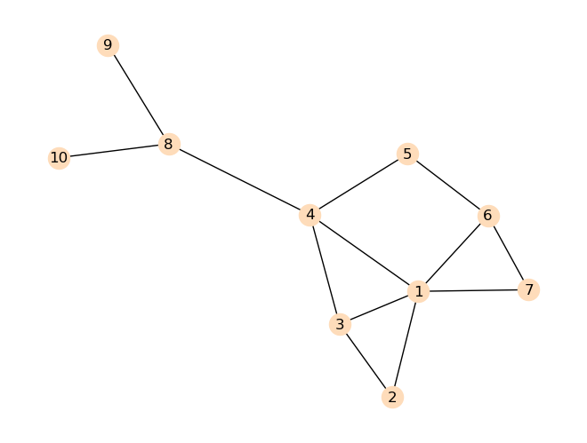

```python
### YOUR CODE for defining G1 GOES HERE:
G1 = nx.Graph([[1,2],[1,3],[1,4],[1,6], [1,7],[2,3],[3,4],[4,5],[5,6],[6,7],[4,8],[8,9],[8,10]])
pos = nx.spring_layout(G1, seed=0) # record for layer use (not essential, but useful)
nx.draw(G1, **opts, pos=pos)
```

### TASK 2.2: Compute Centralities

Compute the Degree, Eigenvector, Closeness, and Betweenness Centralities of the nodes in this graph. Display all four in a table (using a pandas `DataFrame`) sorted by the eigenvector centrality.

```python
### Give your answer for computing the centralities in this cell.
degree_cent = nx.degree_centrality(G1)
evecto_cect = nx.eigenvector_centrality(G1)
closen_cent = nx.closeness_centrality(G1)
betwee_cent = nx.betweenness_centrality(G1)
```

```python
### Give your code for displating the centralities in a table here:
pd.DataFrame({
    'Key': list(degree_cent.keys()),
    'Degree': list(degree_cent.values()),
    'Eigenv': list(evecto_cect.values()),
    'Closen': list(closen_cent.values()),
    'Betwee': list(betwee_cent.values())
}).sort_values('Eigenv', ascending=False)
```

|  | Key | Degree | Eigenv | Closen | Betwee |
| --- | --- | --- | --- | --- | --- |
| 0 | 1 | 0.555556 | 0.544133 | 0.600000 | 0.351852 |
| 3 | 4 | 0.444444 | 0.424131 | 0.642857 | 0.560185 |
| 2 | 3 | 0.333333 | 0.398195 | 0.529412 | 0.064815 |
| 4 | 6 | 0.333333 | 0.333310 | 0.450000 | 0.050926 |
| 1 | 2 | 0.222222 | 0.296646 | 0.409091 | 0.000000 |
| 5 | 7 | 0.222222 | 0.276219 | 0.428571 | 0.000000 |
| 6 | 5 | 0.222222 | 0.238443 | 0.473684 | 0.055556 |
| 7 | 8 | 0.333333 | 0.166524 | 0.500000 | 0.416667 |
| 8 | 9 | 0.111111 | 0.052423 | 0.346154 | 0.000000 |
| 9 | 10 | 0.111111 | 0.052423 | 0.346154 | 0.000000 |

### TASK 2.3: Draw the graph with node size proportional to eigenvector centrality

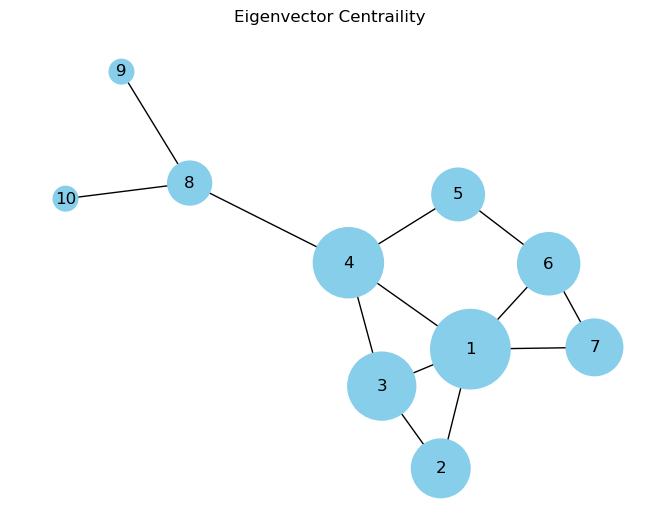

```python
### Give your answer in this cell. Add more cells if needed.
node_sizes = [evecto_cect[node]*6000 for node in G1.nodes()]
nx.draw(G1, with_labels=True, node_size=node_sizes, node_color='skyblue', pos=pos)
plt.title('Eigenvector Centraility')
```

### TASK 2.4: Make your own example

If the previous step worked as intended, you should find that, for $G_1$, Node **4** had both the greatest closeness and betweenness centrality. Make up an example of a graph, $G_2$, which the node with the greatest closeness centrality is different from the one with the greatest betweenness centrality. Define and draw the graph in `networkx`, and compute the centralities to verify your result.

*WARNING* You have to construct this example yourself. Do not try to use the same graph as anyone other than a listed collaborator.

```
{0: 0.47058823529411764, 1: 0.38095238095238093, 2: 0.38095238095238093, 3: 0.47058823529411764, 4: 0.6153846153846154, 5: 0.5714285714285714, 6: 0.38095238095238093, 7: 0.38095238095238093, 8: 0.38095238095238093}
{0: 0.17857142857142855, 1: 0.03571428571428571, 2: 0.03571428571428571, 3: 0.17857142857142855, 4: 0.6071428571428571, 5: 0.6428571428571428, 6: 0.0, 7: 0.0, 8: 0.0}
```

|  | Key | Closen | Betwee |
| --- | --- | --- | --- |
| 4 | 4 | 0.615385 | 0.607143 |
| 5 | 5 | 0.571429 | 0.642857 |
| 0 | 0 | 0.470588 | 0.178571 |
| 3 | 3 | 0.470588 | 0.178571 |
| 2 | 2 | 0.380952 | 0.035714 |
| 1 | 1 | 0.380952 | 0.035714 |
| 6 | 6 | 0.380952 | 0.000000 |
| 7 | 7 | 0.380952 | 0.000000 |
| 8 | 8 | 0.380952 | 0.000000 |

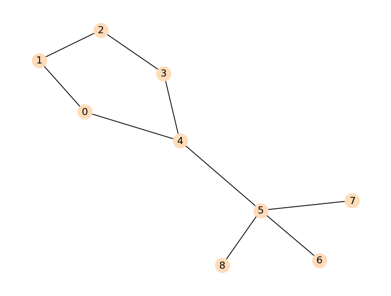

```python
### Give your answer in this cell. Make sure your network is called G2

## Solution: key idea is the make two very different types of graphs (in this case, a cycle and a star, and then
# join them by a bridge. In this example Node 4 has the greatest Closeness, and Node 5 has the greatest Betweenness.

G2 = nx.Graph([[0,1],[1,2],[2,3],[3,4],[4,0], [4,5],[5,6],[5,7],[5,8]])
nx.draw(G2, **opts)

closen_cent = nx.closeness_centrality(G2)
betwee_cent = nx.betweenness_centrality(G2)

# Can just print the central (DataFrame not really necessary)
print(f"{closen_cent}")
print(f"{betwee_cent}")

pd.DataFrame({
    'Key': list(closen_cent.keys()),
    'Closen': list(closen_cent.values()),
    'Betwee': list(betwee_cent.values())
}).sort_values('Closen', ascending=False)
```

Don't remove the following cell. It will plot your network, `G2`, and identify the nodes with greatest betweenness and closeness centralities.

```
Node 5 has the greatest betweenness, and Node 4 has the max closeness
```

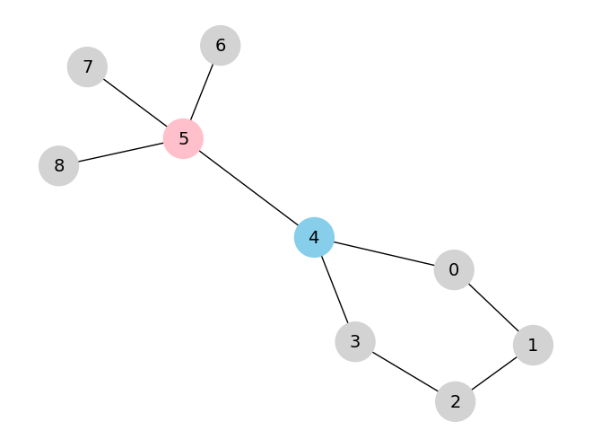

```python
### Do not delete this cell. It has an overly-elaborate way of showing the difference in centralities.
CC = nx.closeness_centrality(G2)
BC = nx.betweenness_centrality(G2)

max_betweenness = max(BC, key=BC.get)
max_closeness = max(CC, key=CC.get)
print(f"Node {max_betweenness} has the greatest betweenness, and Node {max_closeness} has the max closeness")
# Node colors: highlight key nodes
node_colors = []
for node in G2.nodes():
    if node == max_betweenness:
        node_colors.append("pink")  # Highest betweenness
    elif node == max_closeness:
        node_colors.append("skyblue")  # Highest closeness
    else:
        node_colors.append("lightgray")

nx.draw(G2, with_labels=True, node_color=node_colors, edge_color="black", node_size=1000, font_size=14)
```

## Random Networks

We'll learn in class that one way in which ER models don't reflect some real-world networks in that they tend to have fewer triangles (3-cycles) than real-world graphs. Here a *triangle* in $G$ means a subgraph that is isomorphic to $C_3$. So, for example, $C_3$ has 1 triangle, and the [Wheel Graph, $W_n$](https://en.wikipedia.org/wiki/Wheel_graph) has $n-1$.

Asides:

- It is not a homework question, but work out why you should divide the trace of $B$ by 6.
- Well done: you've just come up with a proof that the trace of the cube of any $0-1$ matrix is divisible by 6.

### TASK 3.1: Count Triangles

Write a function (**with some sensible name of your own choosing**) that takes as its input a graph, and returns the total number of triangles in $G$. Tip: `np.trace()` returns the trace of a 2D numpy array.

```python
### Give your code for defining your function in this cell:
def CountTriangles(G):
    A = nx.adjacency_matrix(G, weight=None).toarray()
    Triangle_count = int(np.trace(A@A@A)/6);
    return(Triangle_count)
```

Verify that your function works by checking that, e.g., the graph returned by `nx.wheel_graph(5)` has 4 triangles.

```python
### Give your code that verifies your function works for a $W_5$.
CountTriangles(nx.wheel_graph(5))
```

```
4
```

### TASK 3.2: Comparing $G_{ER}(n,m)$ with graphs from social science

`networkx` comes with some generators from graphs that are much-studied in the network science. In [Week7: Part 2](https://www.niallmadden.ie/2425-CS4423/W07/CS4423-W07-Part-2.html#Example:-15th-century-Florentine-marriages) we considered the *Florentine Families* graph, which is generate by `nx.florentine_families_graph()`. There are others such as

- The [Karate Club Graph](https://en.wikipedia.org/wiki/Zachary%27s_karate_club) which is generated using `nx.karate_club_graph()`
- The (Les Miserables network)[https://networkx.org/documentation/stable/reference/generated/networkx.generators.social.les_miserables_graph.html] generated by `nx.les_miserables_graph()`

For each of the three networks mentioned above:

- Generate the graph, and output the number of order and size of the network, and the number of triangles it has.
- Use `nx.gnm_random_graph()` to make a graph drawn from $G_{ER}(n,m)$ that has the same size and order. Output how many triangles it has.

```python
### Your answer for the Florentine Families graph goes here.
G_real = nx.florentine_families_graph()
n = G_real.order()
m = G_real.size()
G_nm = nx.gnm_random_graph(n,m)
print(f"FF graph has order {n}, size {m} and {CountTriangles(G_real)} triangles")
print(f"A randomly chosen graph from G({n},{m}) has {CountTriangles(G_nm)} triangles")
```

```
FF graph has order 15, size 20 and 3 triangles
A randomly chosen graph from G(15,20) has 3 triangles
```

```python
### Your answer for the Karate Club network goes here.
G_real = nx.karate_club_graph()
n, m = G_real.order(), G_real.size()
G_nm = nx.gnm_random_graph(n,m)
print(f"Karake club network has order {n}, size {m} and {CountTriangles(G_real)} triangles")
print(f"A randomly chosen graph from G({n},{m}) has {CountTriangles(G_nm)} triangles")
```

```
Karake club network has order 34, size 78 and 45 triangles
A randomly chosen graph from G(34,78) has 13 triangles
```

```python
### Your answer for the Les Mis network goes here.
G_real = nx.les_miserables_graph()
n, m = G_real.order(), G_real.size()
G_nm = nx.gnm_random_graph(n,m)
print(f"Les Mis network has order {n}, size {m} and {CountTriangles(G_real)} triangles")
print(f"A randomly chosen graph from G({n},{m}) has {CountTriangles(G_nm)} triangles")
```

```
Les Mis network has order 77, size 254 and 467 triangles
A randomly chosen graph from G(77,254) has 51 triangles
```

## Extras

The following isn't part of the assignment, but you might find it interesting:

1. Use `np.linspace(0,1,100)` to create an array of probabilities.
2. For $n=100$ make a $G_{ER}(n,p)$ graph with the values of $p$ drawn from above, and count the number of triangles. Call this $T(G)$.
3. I conjecture that $T(G)/m(G) \approx C p^2$, for some constant $C$ that depends on $n$. Try to produce a plot that supports (or refutes) this conjecture, and try to estimate $C$

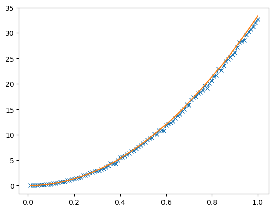

```python
n = 100;
N = math.comb(n,2)
T_count = []
Ps = np.linspace(0.01,1,100)
for p in Ps:
    G = nx.gnp_random_graph(n,p)
    T_count += [CountTriangles(G)/G.size()]

plt.plot(Ps, T_count, marker='x', linestyle='--')
plt.plot(Ps, (n/3)*Ps**2)
```